# Explore Pilot Data

Author

Riccardo Volpato

This document examines whether the reduced 30-item TPSAI scale shows construct validity in the pilot sample, and asks whether item-level responses reveal distinguishable user types beyond what behavioural (usage frequency) or global self-report measures capture on their own.

# Set-up

```r
library(tidyverse)
library(patchwork)
library(knitr)

set.seed(8675309)
```

**Load data**

```r
file_path <- "data/shared/TPSai+-+Pilot.csv"
raw_data  <- read_csv(file_path, n_max = 2)
colnames  <- names(raw_data)
raw_data  <- read_csv(file_path, col_names = colnames, skip = 2)
```

**Response-scale coding**

```r
likert_levels <- c(
  "Strongly disagree"          = 1,
  "Disagree"                   = 2,
  "Somewhat disagree"          = 3,
  "Neither agree nor disagree" = 4,
  "Somewhat agree"             = 5,
  "Agree"                      = 6,
  "Strongly agree"             = 7,
  "Don't know"                 = NA
)

overall_levels <- c(
  "Not at all"  = 1, "Very little" = 2, "A little"    = 3,
  "Moderately"  = 4, "Quite a bit" = 5, "Very much"   = 6,
  "Completely"  = 7
)

freq_groups <- c(
  "Never"                                    = "Never",
  "About once a month"                       = "Rarely",
  "About once a week to a few times a month" = "Rarely",
  "Several times a week"                     = "Often",
  "Daily or multiple times a day"            = "Often"
)

freq_levels <- c(
  "Never"                                    = 1,
  "About once a month"                       = 2,
  "About once a week to a few times a month" = 3,
  "Several times a week"                     = 4,
  "Daily or multiple times a day"            = 5
)

tr_dt_groups <- function(x) {
  cut(x, breaks = c(0, 3, 4, 7),
      labels = c("Low", "Medium", "High"),
      include.lowest = TRUE)
}
```

**Short labels**

```r
freq_labels_short <- c(
  "Never"                                    = "Never",
  "About once a month"                       = "Monthly",
  "About once a week to a few times a month" = "Weekly",
  "Several times a week"                     = "Most days",
  "Daily or multiple times a day"            = "Daily"
)

likert_short <- c(
  "Strongly disagree"          = "Strong disagree",
  "Disagree"                   = "Disagree",
  "Somewhat disagree"          = "Some disagree",
  "Neither agree nor disagree" = "Neutral",
  "Somewhat agree"             = "Some agree",
  "Agree"                      = "Agree",
  "Strongly agree"             = "Strong agree"
)

overall_short <- c(
  "Not at all"  = "Not at all",
  "Very little" = "Very little",
  "A little"    = "A little",
  "Moderately"  = "Moderate",
  "Quite a bit" = "Quite a bit",
  "Very much"   = "Very much",
  "Completely"  = "Completely"
)

f8_short <- c(
  "Psychological Competence" = "COMP",
  "Personalisation"          = "PERS",
  "Artificial Empathy"       = "EMPA",
  "Psychological Safety"     = "SAFE",
  "Risk Perception"          = "RISK",
  "Corporate Distrust"       = "CORP",
  "Sentience Attribution"    = "SENT"
)
```

**Items and factor map**

```r
# Item reduction (see 2a_item_reduction.qmd)
items_to_drop <- c(
  "PERS_04", "PERS_05",            # high inter-item correlation
  "EMPA_05",                       # missingness + low item-factor correlation
  "SAFE_01",                       # high kurtosis
  "RISK_02", "RISK_04",            # high skew
  "CRIT_02", "CRIT_04", "CRIT_05"  # high skew + low item-factor correlation
)

# IMPORTANT: rename raw columns using the FULL factor map (all 39 items
# in survey order), then drop unwanted items by name. Renaming against
# the filtered map would mis-align column positions.
factors_map_full <- read_csv('surveys/pilot-test_qs.csv') |>
  mutate(
    `8F` = case_when(
      IID == "CRIT_01" ~ "Sentience Attribution",
      IID == "CRIT_03" ~ "Risk Perception",
      TRUE ~ `8F`
    ),
    IID = case_when(
      IID == "CRIT_01" ~ "SENT_06",
      IID == "CRIT_03" ~ "RISK_06",
      TRUE ~ IID
    )
  )

factors_map      <- factors_map_full |> filter(!IID %in% items_to_drop)
cols_tpsai_full  <- factors_map_full$IID
survey_cols_full <- sprintf("TPSAI_%d", seq_along(cols_tpsai_full))
cols_tpsai       <- factors_map$IID
f8_levels        <- unique(factors_map$`8F`)
```

**Long-format data with grouping variables**

```r
items_long <- raw_data |>
  mutate(ResponseId = row_number(),
         FREQ_group = factor(freq_groups[FREQ],
                             levels = c("Never", "Rarely", "Often")),
         TR_group   = tr_dt_groups(overall_levels[TR]),
         DT_group   = tr_dt_groups(overall_levels[DT])) |>
  rename_with(~ cols_tpsai_full, all_of(survey_cols_full)) |>
  mutate(across(all_of(cols_tpsai), ~ likert_levels[.x])) |>
  select(ResponseId, FREQ_group, TR_group, DT_group, all_of(cols_tpsai)) |>
  pivot_longer(-c(ResponseId, FREQ_group, TR_group, DT_group),
               names_to = "IID", values_to = "score") |>
  left_join(factors_map, by = "IID")
```

**Plotting helpers**

```r
plot_item_heatmap <- function(data, group_var, x_label = NULL) {
  data |>
    filter(!is.na({{ group_var }}), !is.na(score)) |>
    group_by(IID, {{ group_var }}) |>
    summarise(mean = mean(score), .groups = "drop") |>
    mutate(IID = factor(IID, levels = rev(factors_map$IID))) |>
    ggplot(aes(x = {{ group_var }}, y = IID, fill = mean)) +
    geom_tile(color = "white", linewidth = 0.5) +
    geom_text(aes(label = sprintf("%.1f", mean),
                  color = abs(mean - 4) > 2), size = 3.2) +
    scale_fill_gradient2(low = "#b2182b", mid = "white", high = "#2166ac",
                         midpoint = 4, limits = c(1, 7), name = "Mean") +
    scale_color_manual(values = c("black", "white"), guide = "none") +
    coord_fixed(ratio = 0.5) +
    labs(x = x_label, y = NULL) +
    theme_minimal(base_size = 11) +
    theme(panel.grid = element_blank(),
          axis.text.y = element_text(size = 9))
}

plot_2f_lines <- function(data, group_var, x_label = NULL) {
  data |>
    filter(!is.na({{ group_var }}), !is.na(score)) |>
    group_by(ResponseId, `2F`, {{ group_var }}) |>
    summarise(person_score = mean(score), .groups = "drop") |>
    group_by(`2F`, {{ group_var }}) |>
    summarise(mean = mean(person_score),
              se   = sd(person_score) / sqrt(n()),
              .groups = "drop") |>
    ggplot(aes(x = {{ group_var }}, y = mean,
               group = `2F`, color = `2F`)) +
    geom_ribbon(aes(ymin = mean - se, ymax = mean + se, fill = `2F`),
                alpha = 0.15, color = NA) +
    geom_line() +
    geom_point(size = 2) +
    labs(x = x_label, y = "Mean score") +
    theme_minimal()
}
```

# Construct validity

The scale’s 2-factor structure (Trust / Distrust) is supported across three criterion measures

1. Frequency of generative AI for psychological support
2. Single-item global Trust (TR) for psychological support
3. single-item global Distrust (DT) for psychological support

**Item-level patterns**

[figure not shown]

```r
plot_item_heatmap(items_long, FREQ_group, "Frequency") +
plot_item_heatmap(items_long, TR_group, "TR") +
  theme(axis.text.y = element_blank()) +
plot_item_heatmap(items_long, DT_group, "DT") +
  theme(axis.text.y = element_blank()) +
plot_layout(ncol = 3, guides = "collect") &
theme(legend.position = "right")
```

**Subscale-level patterns**

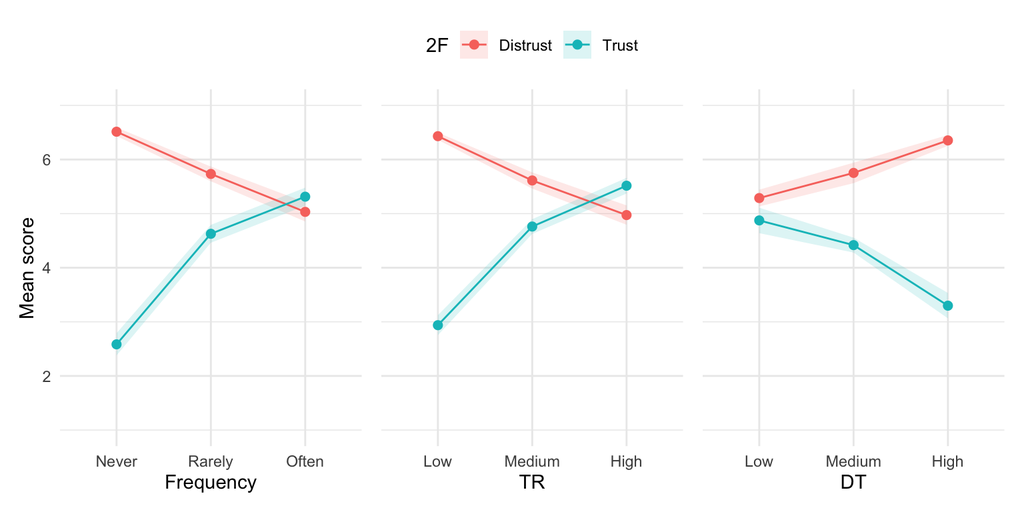

```r
p1 <- plot_2f_lines(items_long, FREQ_group, "Frequency") +
  theme_minimal()

p2 <- plot_2f_lines(items_long, TR_group, "TR") +
  theme_minimal() +
  theme(axis.text.y = element_blank(), axis.title.y = element_blank())

p3 <- plot_2f_lines(items_long, DT_group, "DT") +
  theme_minimal() +
  theme(axis.text.y = element_blank(), axis.title.y = element_blank())

p1 + p2 + p3 + plot_layout(ncol = 3, guides = "collect") &
  scale_y_continuous(limits = c(1, 7)) &
  theme(legend.position = "top")
```

**Frequency vs. global Trust / Distrust**

```r
overall_scores <- raw_data |>
  mutate(FREQ_num = freq_levels[FREQ],
         Trust    = overall_levels[TR],
         Distrust = overall_levels[DT]) |>
  select(FREQ_num, Trust, Distrust) |>
  filter(!is.na(FREQ_num))
```

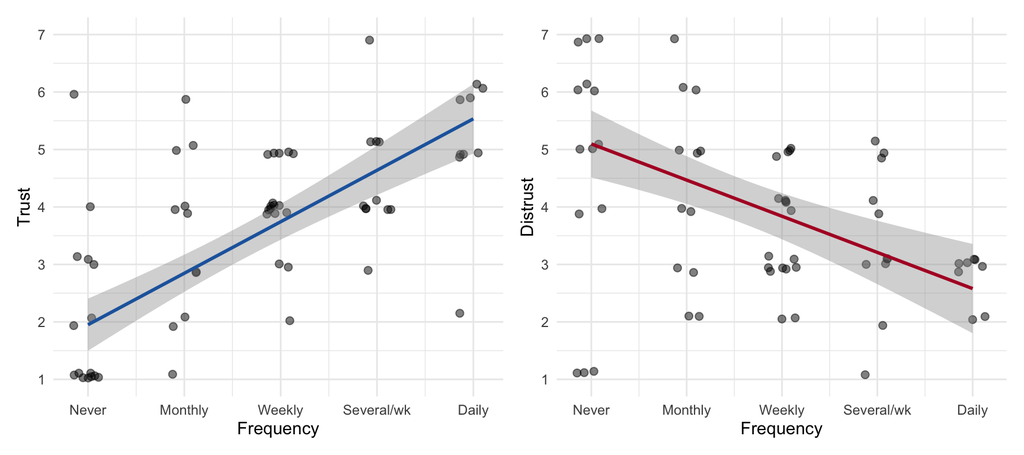

```r
p_trust <- overall_scores |>
  filter(!is.na(Trust)) |>
  ggplot(aes(x = FREQ_num, y = Trust)) +
  geom_jitter(width = 0.15, height = 0.15, alpha = 0.5, size = 2) +
  geom_smooth(method = "lm", se = TRUE, color = "#2166ac") +
  labs(x = "Frequency", y = "Trust")

p_distrust <- overall_scores |>
  filter(!is.na(Distrust)) |>
  ggplot(aes(x = FREQ_num, y = Distrust)) +
  geom_jitter(width = 0.15, height = 0.15, alpha = 0.5, size = 2) +
  geom_smooth(method = "lm", se = TRUE, color = "#b2182b") +
  labs(x = "Frequency", y = "Distrust")

p_trust + p_distrust &
  scale_x_continuous(breaks = 1:5,
                     labels = c("Never", "Monthly", "Weekly",
                                "Several/wk", "Daily")) &
  scale_y_continuous(limits = c(1, 7), breaks = 1:7) &
  theme_minimal(base_size = 11)
```

The three criterion measures are themselves correlated: more frequent AI use for psychological support is associated with higher global Trust and lower global Distrust (also for psychological support).

# Clustering

Construct validity establishes that the scale measures what it claims to measure at the *group* level. A complementary question is whether the 30 items reveal distinguishable *types* of respondents — patterns of trust and distrust that don’t reduce to a single dimension. We address this by hierarchical clustering on the 30 items, then describing the resulting clusters by their behavioural and global self-report profiles.

“Don’t know” responses are imputed to the scale midpoint (4 = Neither agree nor disagree), treating them as ambivalence rather than borrowing from other respondents.

```r
items_wide <- items_long |>
  select(ResponseId, IID, score) |>
  mutate(score = replace_na(score, 4)) |>
  pivot_wider(names_from = IID, values_from = score)

X <- items_wide |> select(-ResponseId) |> as.matrix()
rownames(X) <- items_wide$ResponseId

d  <- dist(X, method = "euclidean")
hc <- hclust(d, method = "ward.D2")

cluster_assignments <- tibble(
  ResponseId = items_wide$ResponseId,
  k2 = cutree(hc, k = 2),
  k3 = cutree(hc, k = 3),
  k4 = cutree(hc, k = 4)
)
```

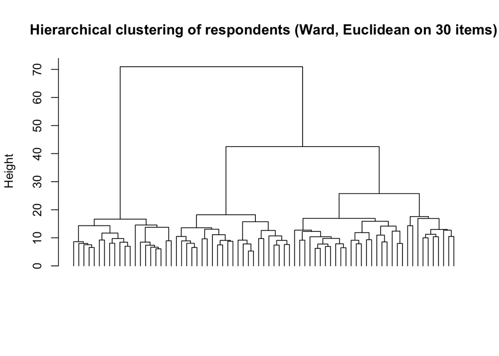

```r
plot(hc, labels = FALSE, hang = -1,
     main = "Hierarchical clustering of respondents (Ward, Euclidean on 30 items)",
     xlab = "", sub = "")
```

## Cluster profiles

```r
# Relabel cluster_assignments by trust rank: cluster 1 = lowest trust,
# cluster k = highest. Same psychological position gets the same number
# (and colour) across all values of k.
relabel_by_trust <- function(k_col) {
  ranks <- items_long |>
    filter(!is.na(score), `2F` == "Trust") |>
    inner_join(cluster_assignments |> select(ResponseId, all_of(k_col)),
               by = "ResponseId") |>
    group_by(cluster_num = .data[[k_col]]) |>
    summarise(trust_mean = mean(score, na.rm = TRUE), .groups = "drop") |>
    arrange(trust_mean) |>
    mutate(new_num = row_number()) |>
    select(cluster_num, new_num)

  cluster_assignments[[k_col]] <<- ranks$new_num[
    match(cluster_assignments[[k_col]], ranks$cluster_num)
  ]
}

walk(c("k2", "k3", "k4"), relabel_by_trust)
```

```r
likert_labels <- names(likert_levels)[1:7]  # drops "Don't know"

profiles <- raw_data |>
  mutate(ResponseId  = row_number(),
         FREQ_label  = FREQ,
         TR_label    = TR,
         DT_label    = DT,
         FREQ_num    = freq_levels[FREQ],
         TR_num      = overall_levels[TR],
         DT_num      = overall_levels[DT]) |>
  select(ResponseId, starts_with("FREQ"), starts_with("TR"),
         starts_with("DT")) |>
  inner_join(cluster_assignments, by = "ResponseId") |>
  left_join(
    items_long |>
      filter(!is.na(score)) |>
      group_by(ResponseId, `2F`) |>
      summarise(score = mean(score), .groups = "drop") |>
      pivot_wider(names_from = `2F`, values_from = score),
    by = "ResponseId"
  )

summarise_k <- function(k) {
  profiles |>
    group_by(Cluster = .data[[k]]) |>
    summarise(
      N = n(),
      Frequency = sprintf(
        "%s (%.1f)",
        freq_labels_short[names(freq_levels)[round(mean(FREQ_num, na.rm = TRUE))]],
        mean(FREQ_num, na.rm = TRUE)
      ),
      `Trust Item` = sprintf(
        "%s (%.1f)",
        overall_short[names(overall_levels)[round(mean(TR_num, na.rm = TRUE))]],
        mean(TR_num, na.rm = TRUE)
      ),
      `Trust Scale` = sprintf(
        "%s (%.1f)",
        likert_short[likert_labels[round(mean(Trust, na.rm = TRUE))]],
        mean(Trust, na.rm = TRUE)
      ),
      `Distrust Item` = sprintf(
        "%s (%.1f)",
        overall_short[names(overall_levels)[round(mean(DT_num, na.rm = TRUE))]],
        mean(DT_num, na.rm = TRUE)
      ),
      `Distrust Scale` = sprintf(
        "%s (%.1f)",
        likert_short[likert_labels[round(mean(Distrust, na.rm = TRUE))]],
        mean(Distrust, na.rm = TRUE)
      ),
      .groups = "drop"
    ) |>
    arrange(Cluster)
}
```

```r
plot_cluster_profile <- function(k_col) {
  plot_data <- items_long |>
    filter(!is.na(score)) |>
    inner_join(cluster_assignments |> select(ResponseId, all_of(k_col)),
               by = "ResponseId") |>
    rename(cluster = all_of(k_col)) |>
    group_by(ResponseId, `8F`, cluster) |>
    summarise(person_score = mean(score), .groups = "drop") |>
    group_by(`8F`, cluster) |>
    summarise(mean = mean(person_score),
              se   = sd(person_score) / sqrt(n()),
              .groups = "drop") |>
    mutate(`8F`    = factor(f8_short[`8F`], levels = f8_short),
         cluster = factor(cluster, levels = c("1", "2", "3", "4")))

  present_clusters <- sort(unique(as.character(plot_data$cluster)))

  ggplot(plot_data,
         aes(x = `8F`, y = mean, color = cluster, group = cluster)) +
    geom_ribbon(aes(ymin = mean - se, ymax = mean + se, fill = cluster),
                alpha = 0.15, color = NA) +
    geom_line() +
    geom_point(size = 2) +
    scale_color_brewer(palette = "RdYlBu", drop = FALSE,
                       breaks = rev(present_clusters), direction = 1) +
    scale_fill_brewer(palette = "RdYlBu", drop = FALSE,
                      breaks = rev(present_clusters), direction = 1) +
    scale_y_continuous(limits = c(1, 7)) +
    labs(x = NULL, y = "Mean", color = "Cluster", fill = "Cluster") +
    theme_minimal(base_size = 11) +
    theme(legend.position = "right",
          axis.title.y    = element_text(color = "grey40"),
          legend.title    = element_text(color = "grey40"),
          axis.text.x = element_text(angle = 90, hjust = 1, vjust = 0.5))
}
```

### k = 2

A primary split between engaged users with positive attitudes and disengaged users with negative attitudes — the expected first-order pattern.

```r
summarise_k("k2") |> kable(digits = 2)
```

| Cluster | N | Frequency | Trust Item | Trust Scale | Distrust Item | Distrust Scale |
| --- | --- | --- | --- | --- | --- | --- |
| 1 | 20 | Never (1.1) | Not at all (1.1) | Disagree (2.1) | Quite a bit (5.3) | Strong agree (6.6) |
| 2 | 55 | Weekly (3.1) | Moderate (4.2) | Some agree (4.9) | Moderate (3.7) | Agree (5.5) |

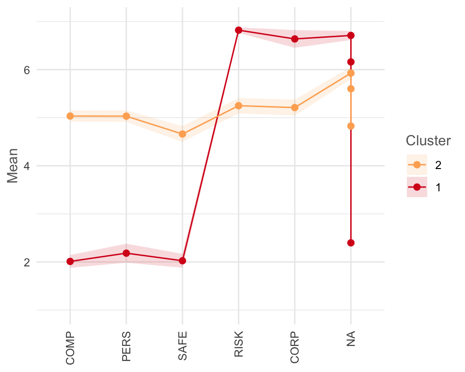

```r
plot_cluster_profile("k2")
```

### k = 3

```r
summarise_k("k3") |> kable(digits = 2)
```

| Cluster | N | Frequency | Trust Item | Trust Scale | Distrust Item | Distrust Scale |
| --- | --- | --- | --- | --- | --- | --- |
| 1 | 20 | Never (1.1) | Not at all (1.1) | Disagree (2.1) | Quite a bit (5.3) | Strong agree (6.6) |
| 2 | 23 | Monthly (2.3) | A little (3.3) | Neutral (4.2) | Quite a bit (4.6) | Agree (6.2) |
| 3 | 32 | Most days (3.7) | Quite a bit (4.8) | Some agree (5.4) | A little (3.0) | Some agree (5.0) |

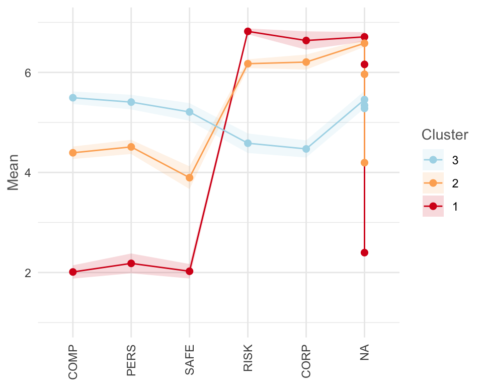

```r
plot_cluster_profile("k3")
```